# FLicc 1.0.6 – 1.0.9: Growth groups, robust likelihood, biomass-scale status, fast reference points and MSE tools

Henning Winker (FAO-NFI)

07 October 2026

# 1 Overview

This document describes the changes to `FLicc` between versions 1.0.5 and 1.0.9. All examples run on the `alfonsino` example data with the GTG population model, so every number shown here is produced by the current code.

| Version | Change | Default results changed? |
| --- | --- | --- |
| 1.0.6 | GTG survival now uses the estimated Linf, M/K and CVL | Only for fits with `linf.sd`, `Mk.sd` or `CVL.sd` |
| 1.0.7 | Robust likelihood options `rob_eps` and `Lplus`; optional warning for unreachable fish (`tail_warning`) | No |
| 1.0.8 | Steepness option `flicc2FLStockR(s = )`; `spr2brel()`, `sprbrel_flicc()`, `fbrel_flicc()` | No (`s = NULL` by default) |
| 1.0.9 | Per-recruit calculations in TMB; Fspr reported by the fit (`spr_ref`); `brp_tmb_flicc()`; MSE tools `flicc.sa()`, `lbi.hcr()`, `flicc.is()` and HCR helpers; `fit$report$N` first dimension named `len` | No (same results, much faster) |

The GTG defaults remain those of LBSPR (`maxsd = 2`, `ngtg = 13`); Section 3 explains what they imply and when to change them.

```r
library(FLicc)

data("alfonsino")
lfd <- FLQuantLen(lfd_long_to_wide(as.data.frame(lfd_alfonsino)),
                  unit = "cm", midL = FALSE)
lhpar <- FLPar(linf = 55.7, k = 0.08, M = 0.162, L50 = 31.1859,
               a = 0.004721956 / 1000, b = 3.146168)
stklen <- stocklen(lfd, lhpar, m_model = "constant")

sel_fun <- c("dsnormal", "logistic")
cbg     <- c(0.7, 0.3)
base    <- list(prior_sigmaF = c(log(0.5), 0.3, 1), CVL = 0.1)

# helper: fit with the base settings plus any extra settings
fitf <- function(...) fiticc(lfd, stklen, sel_fun = sel_fun,
                             catch_by_gear = cbg, settings = c(base, list(...)))
lastspr <- function(fit) round(tail(c(fit$report$spr), 1), 4)
```

# 2 GTG survival uses the estimated life-history parameters (1.0.6)

## 2.1 What changed

For `pop_model = "gtg"`, the Linf of each growth-type group (GTG), the recruitment weights and the M/K matrix were previously built in R from the **input** values and passed to TMB as fixed data. With `linf.sd` or `Mk.sd`, Linf and M/K were estimated but only reached selectivity scaling and the F/M penalty, not GTG survival, and CVL could not be estimated for GTG at all.

Now the template builds them from the current parameters:

$$L_{\infty,g} = L_\infty\,(1 + CV_L\, z_g), \qquad M/K(L) = M_k \left(\frac{L_\infty}{L}\right)^{M_{\text{pow}}}$$

on a fixed standardised grid $z_g$. Priors on Linf, M/K and CVL (`linf.sd`, `Mk.sd`, `CVL.sd`) now act on the population model, and CVL is estimated for GTG when `CVL.sd` is given (as for the gamma model).

```r
fit.fix <- fitf()                                           # Linf, M/K, CVL fixed
fit.est <- fitf(linf.sd = 0.1, Mk.sd = 0.2, CVL.sd = 0.2)    # estimated

rbind(fixed     = c(Linf = c(fit.fix$report$lhpar["linf"]), Mk = c(fit.fix$report$lhpar["Mk"]),
                    CVL = c(fit.fix$report$pars["CVL"]), SPR = lastspr(fit.fix)),
      estimated = c(Linf = c(fit.est$report$lhpar["linf"]), Mk = c(fit.est$report$lhpar["Mk"]),
                    CVL = c(fit.est$report$pars["CVL"]), SPR = lastspr(fit.est)))
```

```
#>              Linf       Mk        CVL    SPR
#> fixed     55.7000 2.025000 0.10000000 0.2527
#> estimated 53.9512 1.326974 0.09152639 0.1199
```

**GTG fits made before 1.0.6 with `linf.sd`, `Mk.sd` or `CVL.sd` should be rerun**: the life-history estimates they reported did not affect SPR. Fits with these parameters fixed (the default) are unchanged.

Two smaller fixes came with this: the GTG length floors use `CppAD::CondExpLe` so they remain correct when the GTG Linfs depend on parameters, and a zero lower bin boundary no longer gives infinite M/K when `Mpow > 0`.

# 3 GTG tails: what `maxsd` and `ngtg` do

## 3.1 How the GTG represents growth variation

Each GTG is a single growth curve with no variation of its own; all variation comes from the spread of Linf across groups. `CVL` sets the scale ($\sigma = CV_L \cdot L_\infty$) and `maxsd` how far out the outermost groups sit, in units of $\sigma$ (λ in Hordyk et al. 2016, fixed at 2 in LBSPR). `ngtg` only sets how finely that range is divided. The defaults remain those of LBSPR, `maxsd = 2` and `ngtg = 13`.

Cutting the normal distribution at ±`maxsd` makes the actual spread smaller than `CVL` and caps the largest length the model can produce at $L_\infty(1 + \text{maxsd} \cdot CV_L)$:

Effect of truncating the GTG Linf distribution (continuous normal).

| maxsd | actual CV / CVL | largest Linf at CVL 0.1 (x Linf) |
| --- | --- | --- |
| 1.0 | 0.540 | 1.10 |
| 1.5 | 0.743 | 1.15 |
| 2.0 | 0.880 | 1.20 |
| 2.5 | 0.955 | 1.25 |
| 3.0 | 0.987 | 1.30 |

With the default `maxsd = 2`, a CVL of 0.10 is effectively about 0.09. SPR depends strongly on that spread, so CVL values taken from other sources (e.g. an integrated assessment) should be interpreted with this in mind. `maxsd = 3, ngtg = 19` makes CVL close to the actual spread.

```r
fit.wide <- fitf(maxsd = 3, ngtg = 19)
fit.ng30 <- fitf(maxsd = 3, ngtg = 30)

cv_gtg <- function(fit) {                     # actual CV of the GTG Linf distribution
  L <- fit$report$gtgLinfs; w <- fit$report$recP
  sqrt(sum(w * (L - sum(w * L))^2)) / sum(w * L)
}
data.frame(setting = c("maxsd 2, ngtg 13 (default, LBSPR)", "maxsd 3, ngtg 19", "maxsd 3, ngtg 30"),
           actual_CV = round(sapply(list(fit.fix, fit.wide, fit.ng30), cv_gtg), 3),
           SPR = sapply(list(fit.fix, fit.wide, fit.ng30), lastspr))
```

```
#>                             setting actual_CV    SPR
#> 1 maxsd 2, ngtg 13 (default, LBSPR)     0.091 0.2527
#> 2                  maxsd 3, ngtg 19     0.099 0.2457
#> 3                  maxsd 3, ngtg 30     0.099 0.2459
```

`ngtg` hardly matters beyond about 9–13 groups; `maxsd` acts through the actual spread.

# 4 Optional warning for fish beyond the largest GTG Linf (1.0.7)

The GTG model cannot produce fish longer than its largest group’s Linf, so observations in bins at or above it get near-zero probability. A few such fish can dominate the likelihood, create steps in CVL profiles and drive status estimates. With `tail_warning = TRUE`, `fiticc()` warns when this happens (off by default):

```r
w <- NULL
fit.narrow <- withCallingHandlers(fitf(maxsd = 0.5, ngtg = 7, tail_warning = TRUE),
  warning = function(x) { w <<- c(w, conditionMessage(x)); invokeRestart("muffleWarning") })
cat(w[grepl("largest GTG Linf", w)])
```

```
#> 1 observed fish (0.0% of the total) lie in length bins at or above the largest GTG Linf (58.5 = Linf * (1 + maxsd * CVL)); the model gives them near-zero probability, which can drive CVL and status estimates. Consider a larger maxsd, settings$Lplus or settings$rob_eps.
```

# 5 Robust likelihood options (1.0.7)

Two options reduce the influence of the largest fish on the composition likelihood. Both are off by default and work with the `nb`, `mn` and `dm` observation models.

- **`rob_eps`** mixes the predicted proportions with a small uniform probability,
  $$\tilde p_l = (1 - \varepsilon)\, p_l + \varepsilon / n_{\text{bins}},$$
  which bounds the cost of a few fish in bins the model barely reaches.
- **`Lplus`** pools observed and predicted counts in all bins with lower bound $\geq$ `Lplus` into one plus group before the likelihood (tail compression, as in SS3). The likelihood then only sees how many fish are at or above `Lplus`, not how they fall into bins. Predicted compositions in the report and plots stay unpooled.

```r
rob <- list(
  dm              = fitf(obs_model = "dm"),
  rob0.001        = fitf(obs_model = "dm", rob_eps = 0.001),
  rob0.01         = fitf(obs_model = "dm", rob_eps = 0.01),
  plus45          = fitf(obs_model = "dm", Lplus = 45),
  plus45_rob0.001 = fitf(obs_model = "dm", Lplus = 45, rob_eps = 0.001))

data.frame(nll = sapply(rob, function(f) round(f$opt$objective, 2)),
           SPR = sapply(rob, lastspr),
           Fspr40 = sapply(rob, function(f) round(fspr_flicc(f), 4)))
```

```
#>                      nll    SPR Fspr40
#> dm              35702.32 0.2722 0.0806
#> rob0.001        35692.01 0.2731 0.0831
#> rob0.01         35695.78 0.2693 0.0853
#> plus45          35129.32 0.2619 0.0796
#> plus45_rob0.001 35118.76 0.2642 0.0823
```

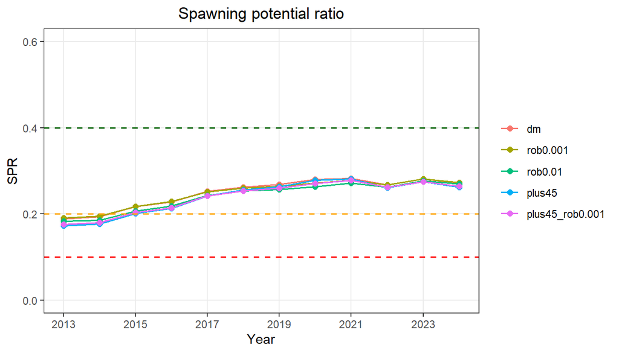

```r
plot_spr(rob)
```

With well-behaved data, as here, the options change results little; they are insurance against sparse or outlying upper-tail bins rather than a tuning device. Guidance:

- `rob_eps = 0.001` is a safe value; larger values (0.01) start to affect fitted selectivity and F even with clean data.
- Choose `Lplus` where counts become sparse, typically around Linf.
- Compare negative log-likelihoods only between fits with the same `Lplus`: pooling changes the data the likelihood sees.

# 6 Biomass-scale status under steepness (1.0.8)

## 6.1 Why SPR/SPR40 overstates depleted stocks

Under Beverton–Holt recruitment with steepness $s$, equilibrium spawning biomass is linear in SPR but does not pass through zero:

$$\frac{B}{B_0} = \frac{4 s\, \text{SPR} - (1 - s)}{5 s - 1}$$

Recruitment declines as SPR falls, so biomass falls faster than SPR. Status expressed as SPR/SPR40 is therefore optimistic at low stock size, and SPR-based limits such as SPR10 sit far below a quarter of the biomass target.

```r
s <- 0.75
data.frame(SPR = c(0.40, 0.30, 0.20, 0.15, 0.10),
           `SPR/SPR40` = c(0.40, 0.30, 0.20, 0.15, 0.10) / 0.4,
           `B/B40` = round(spr2brel(c(0.40, 0.30, 0.20, 0.15, 0.10), s = s), 3),
           check.names = FALSE)
```

```
#>    SPR SPR/SPR40 B/B40
#> 1 0.40     1.000 1.000
#> 2 0.30     0.750 0.684
#> 3 0.20     0.500 0.368
#> 4 0.15     0.375 0.211
#> 5 0.10     0.250 0.053
```

```r
sprbrel_flicc(c(1, 0.5, 0.25), s = s)     # SPR (%) giving B/B40 = 1, 0.5, 0.25
```

```
#> [1] 40.00000 24.16667 16.25000
```

## 6.2 Functions

- `spr2brel(spr, s, sprref = 40)` converts SPR to equilibrium biomass relative to the biomass at a reference SPR (use `100 * SPRmsy` for B/Bmsy).
- `sprbrel_flicc(brel, s, sprref = 40)` gives the SPR (%) at which biomass is `brel` times the reference.
- `fbrel_flicc(fit, brel, s, sprref = 40)` gives the F at which biomass is `brel` times the reference; it is as fast as `fspr_flicc()`.
- `flicc2FLStockR(fit, ..., s = NULL)`: with `s` given, the stock slot and `Bspr` become equilibrium biomass (B/B0, or B/Btgt with `rel = TRUE`), and `Bpa` and `Blim` keep their fractions of the target on the biomass scale. `Fspr` is unchanged. With `s = NULL` the behaviour is as before.

```r
c(F_at_0.25_B40 = fbrel_flicc(fit.fix, brel = 0.25, s = s),
  Fspr10 = fspr_flicc(fit.fix, spr = 10))
```

```
#> F_at_0.25_B40        Fspr10
#>     0.1782189     0.2387729
```

```r
stk.spr <- flicc2FLStockR(fit.fix, rel = TRUE)           # SPR / SPR40
stk.b   <- flicc2FLStockR(fit.fix, rel = TRUE, s = s)    # B / B40 under s = 0.75
rbind(`SPR/SPR40` = round(tail(c(stk.spr@stock), 5), 3),
      `B/B40`     = round(tail(c(stk.b@stock), 5), 3))
```

```
#>            [,1]  [,2]  [,3]  [,4]  [,5]
#> SPR/SPR40 0.713 0.743 0.604 0.722 0.632
#> B/B40     0.638 0.675 0.500 0.649 0.535
```

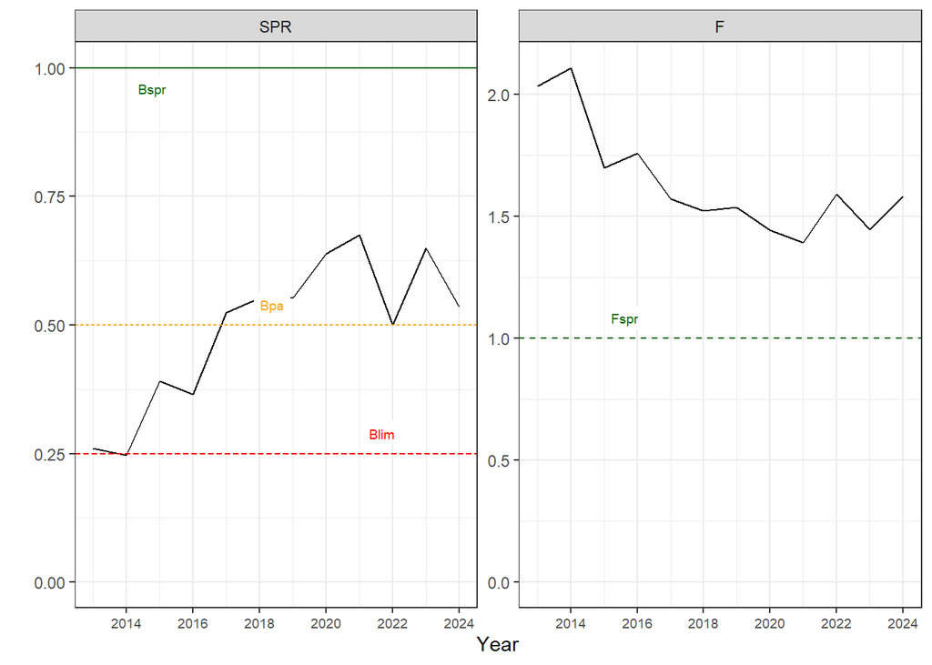

```r
plot_LBAdvice(stk.b)
```

The conversion is an equilibrium measure. During a recovery, actual biomass lags behind, so some difference to dynamic B/Bmsy remains even after the correction.

# 7 Fast reference points in TMB (1.0.9)

## 7.1 What changed

The R per-recruit functions ran many population recursions in R with FLQuant overhead: `fspr_flicc()` recomputed the unfished state at every `uniroot()` step, and `prbrp_flicc()` looped over 101 F values. This slowed `flicc2FLStockR()`, `LBIspr()` and `eqstklen()`, which are used repeatedly in simulation testing and `flicc.sa()`.

- The TMB template has an optional per-recruit block, evaluated only in TMB’s double evaluation (`obj$report()`) and never during optimisation. It computes numbers, catch and F at length, YPR and SBPR for a vector of F (or F/M), and Fspr for target SPRs, at the fitted parameters, for both population models.
- **`settings$spr_ref`** (default `40`, may be a vector): the fit reports `fit$report$Fspr` and per-recruit numbers-at-length at Fspr. `fspr_flicc()` returns the stored value for these targets, and `LBIspr()` and `flicc2FLStockR()` need no per-recruit computation at the target.
- **`brp_tmb_flicc()`** does the same for any F values or targets in one TMB call. `spr_flicc()`, `pr_flicc()`, `nf_flicc()` and `prbrp_flicc()` (and through them `eqstklen()`) use it.
- `flicc.sa()` sets `spr_ref` to its `spr` target automatically, so `LBIspr()` inside the management procedure reuses the stored Fspr.
- The previous R implementation remains as a fallback for non-default options (`Sel`, `scale_sel = FALSE`), for fits from earlier versions, and with `options(FLicc.brp_tmb = FALSE)`.

```r
fit.sp <- fitf(spr_ref = c(40, 20, 10))
fit.sp$report$Fspr
```

```
#>     Fspr40     Fspr20     Fspr10
#> 0.08097687 0.15413099 0.23877290
```

```r
b <- brp_tmb_flicc(fit.sp, Fseq = c(0, 0.05, 0.1, 0.2), spr = c(40, 30))
b$Fspr                       # F at SPR 40% and 30%
```

```
#> [1] 0.08097687 0.11002546
```

```r
round(b$SBPR / b$SBPR0, 4)   # SPR at the F values
```

```
#> [1] 1.0000 0.5554 0.3306 0.1357
```

## 7.2 Speed and agreement with the previous implementation

```r
timeit <- function() {
  t <- c(fspr40 = system.time(a1 <- fspr_flicc(fit.sp, spr = 40))[["elapsed"]],
         prbrp  = system.time(a2 <- prbrp_flicc(fit.sp))[["elapsed"]],
         eqstklen = system.time(a3 <- eqstklen(fit.sp, s = s))[["elapsed"]],
         LBIspr = system.time(a4 <- LBIspr(fit.sp))[["elapsed"]],
         flicc2FLStockR = system.time(a5 <- flicc2FLStockR(fit.sp))[["elapsed"]])
  list(t = t, v = list(Fspr40 = a1, SBPR = c(a2$SBPR), refpts = c(a3@refpts)))
}
options(FLicc.brp_tmb = FALSE); old <- timeit()     # previous R implementation
options(FLicc.brp_tmb = TRUE);  new <- timeit()     # TMB

knitr::kable(rbind(`old (s)` = old$t, `new (s)` = new$t,
                   speedup = round(old$t / pmax(new$t, 1e-3))),
             caption = "Elapsed time on this machine (seconds).")
```

Elapsed time on this machine (seconds).

|  | fspr40 | prbrp | eqstklen | LBIspr | flicc2FLStockR |
| --- | --- | --- | --- | --- | --- |
| old (s) | 0.62 | 2.67 | 3.43 | 0.65 | 0.67 |
| new (s) | 0.00 | 0.04 | 0.12 | 0.05 | 0.06 |
| speedup | 620.00 | 67.00 | 29.00 | 13.00 | 11.00 |

```r
reldiff <- function(a, b) max(abs(a - b) / pmax(abs(b), 1e-12), na.rm = TRUE)
sapply(names(new$v), function(k) signif(reldiff(new$v[[k]], old$v[[k]]), 3))
```

```
#>   Fspr40     SBPR   refpts
#> 1.65e-04 6.54e-16 1.65e-04
```

# 8 Management procedure tools for `mse` (1.0.9)

These functions plug an FLicc length-based assessment and an empirical harvest control rule into the `mp()` function of the FLR `mse` package.

[output not shown]

Helpers usable outside `mp()`:

- `spr_rule(spr, b1, b2, b3, b4, dlow, dopt, dhi)`: SPR-based change multiplier with four triggers (fixed reduction below `b1`, linear to the no-change plateau between `b2` and `b3`, linear increase to `b4`, fixed increase above).
- `r_rule(idx, n1, n2)`: trend ratio of an index.
- `hcr_sprlbi(fit, gear, ...)`: the combined rule applied to a single fit.
- `plot_hcrspr(...)`: plot of the SPR rule with status zones.

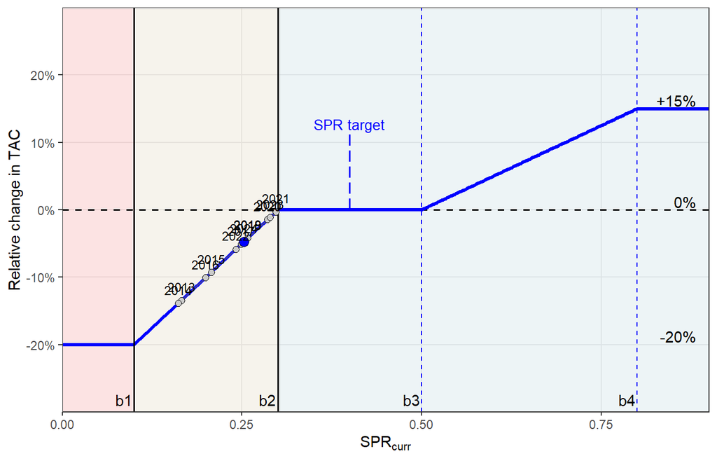

```r
plot_hcrspr(b1 = 0.1, b2 = 0.3, b3 = 0.5, b4 = 0.8, blim = 0.1, bthr = 0.3,
            dlow = -0.2, dopt = 0, dup = 0.15, spr_target = 0.4,
            obs = c(fit.fix$report$spr), years = dimnames(fit.fix$report$spr)$year)
```

```r
idx <- LBIspr(fit.fix)
round(c(trend_ratio_Trawl = r_rule(idx[["Trawl"]]),
        spr_multiplier = spr_rule(tail(c(fit.fix$report$spr), 1)),
        combined_Trawl = hcr_sprlbi(fit.fix, gear = "Trawl")), 3)
```

```
#> trend_ratio_Trawl    spr_multiplier    combined_Trawl
#>             0.682             0.953             0.922
```

A management procedure using these components (the operating model `om` and an observation error model `oem` that attaches `lfd` and `catch_gear` to the stock are required and not shown):

```r
library(mse)

ctrl <- mpCtrl(list(
  est  = mseCtrl(method = flicc.sa,
                 args = list(lhpar = lhpar, sel_fun = c("dsnormal", "logistic"),
                             settings = list(pop_model = "gtg", obs_model = "dm"),
                             spr = 40, thresh = 0.75, ess.g = 150, nyrs = 5)),
  hcr  = mseCtrl(method = lbi.hcr,
                 args = list(gear = "Trawl", b1 = 0.1, b2 = 0.3, b3 = 0.5, b4 = 0.75,
                             dlow = -0.2, dopt = 0, dhi = 0.15, n1 = 2, n2 = 3)),
  isys = mseCtrl(method = flicc.is,
                 args = list(initac = 1000, dtaclow = 0.85, dtacupp = 1.15))))

run <- mp(om, oem, ctrl = ctrl,
          args = list(iy = 2024, fy = 2044, frq = 2, management_lag = 1))
```

With the per-recruit speed work in Section 7, the reference-point part of each assessment (Fspr and the `LBIspr()` reference length distribution) adds almost nothing to the fitting time inside `mp()`.

# 9 Background: the growth-phase proposal

The starting point for this work was a proposal to add variation in the growth origin (“growth phase”) to correct overly narrow predicted length distributions near the origin under year-round sampling. Mapping it against the code showed:

- Both FLicc population models are equilibrium, per-recruit, length-structured models that integrate over a continuum of ages. Pulse recruitment sampled in proportion to catch through the year averages to the same equilibrium length composition, so a growth-phase term has almost no effect on the predicted catch length composition (maximum difference of order 1e-5 in simulation). The SS3 practice of inflating CV at L1 compensates for discrete annual age classes, which the GTG model does not have.
- Variation in growth rate (K), unlike timing, does persist along the length path and matters; the GTG’s CVL then acts as an effective total growth variation.
- When data come from a model without persistent growth groups (fixed CV of length at age), the GTG model tends to underestimate F and overestimate SPR at high F, as reported by Hordyk et al. (2016, Fig. 5).
- SPR-based status is optimistic at low stock size relative to biomass (Section 6), which explains part of the apparent bias against operating-model B/Bmsy.

The remaining development candidates are a Linf × K GTG and a review of other parameter-dependent `if()` statements in the template.

# 10 Other changes and reproducing earlier fits

- `fit$report$N` now has `len` (not `lens`) as its first dimension, consistent with the other length-based report quantities.
- Default GTG fits are unchanged. Only GTG fits with `linf.sd`, `Mk.sd` or `CVL.sd` differ from versions before 1.0.6 (Section 2).

```r
# previous R per-recruit code (results identical apart from uniroot tolerance)
options(FLicc.brp_tmb = FALSE)
```

# 11 References

Hordyk, A.R., Ono, K., Prince, J.D. and Walters, C.J. (2016). A simple length-structured model based on life history ratios and incorporating size-dependent selectivity: application to spawning potential ratios for data-poor stocks. *Canadian Journal of Fisheries and Aquatic Sciences* 73: 1787–1799. https://doi.org/10.1139/cjfas-2015-0422

Kristensen, K., Nielsen, A., Berg, C.W., Skaug, H. and Bell, B.M. (2016). TMB: Automatic Differentiation and Laplace Approximation. *Journal of Statistical Software* 70(5): 1–21. https://doi.org/10.18637/jss.v070.i05